# Bayesian GLMM Part7

Author

Murray Logan

Published

09/09/2025

# 1 Preparations

Load the necessary libraries

```r
library(car) # for regression diagnostics
library(broom) # for tidy output
library(ggfortify) # for model diagnostics
library(knitr) # for kable
library(ggeffects)
library(emmeans) # for estimating marginal means
library(MASS) # for glm.nb
library(tidyverse) # for data wrangling
library(brms)
library(tidybayes)
library(broom.mixed)
library(rstan)
library(cmdstanr)
library(patchwork)
library(DHARMa)
library(easystats)
library(modelsummary)
source("helperFunctions.R")
```

# 2 Scenario

In an honours thesis from (1992), Mullens was investigating the ways that cane toads ( Bufo marinus ) respond to conditions of hypoxia. Toads show two different kinds of breathing patterns, lung or buccal, requiring them to be treated separately in the experiment. Her aim was to expose toads to a range of O<sub>2</sub> concentrations, and record their breathing patterns, including parameters such as the expired volume for individual breaths. It was desirable to have around 8 replicates to compare the responses of the two breathing types, and the complication is that animals are expensive, and different individuals are likely to have different O<sub>2</sub> profiles (leading to possibly reduced power). There are two main design options for this experiment;

- One animal per O<sub>2</sub> treatment, 8 concentrations, 2 breathing types. With 8 replicates the experiment would require 128 animals, but that this could be analysed as a completely randomized design
- One O<sub>2</sub> profile per animal, so that each animal would be used 8 times and only 16 animals are required (8 lung and 8 buccal breathers)

Mullens decided to use the second option so as to reduce the number of animals required (on financial and ethical grounds). By selecting this option, she did not have a set of independent measurements for each oxygen concentration, by repeated measurements on each animal across the 8 oxygen concentrations.

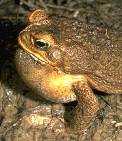

**Figure** 1: Toad

**Table** 1: Format of mullens.csv data file

| BREATH | TOAD | O2LEVEL | FREQBUC | SFREQBUC |
| --- | --- | --- | --- | --- |
| lung | a | 0 | 10.6 | 3.256 |
| lung | a | 5 | 18.8 | 4.336 |
| lung | a | 10 | 17.4 | 4.171 |
| lung | a | 15 | 16.6 | 4.074 |
| ... | ... | ... | ... | ... |

**Table** 2: Description of the variables in the mullens data file

[output not shown]

# 3 Read in the data

```r
mullens <- read_csv("../data/mullens.csv", trim_ws = TRUE)
```

**glimpse**

```r
glimpse(mullens)
```

```
Rows: 168
Columns: 5
$ BREATH   <chr> "lung", "lung", "lung", "lung", "lung", "lung", "lung", "lung…
$ TOAD     <chr> "a", "a", "a", "a", "a", "a", "a", "a", "b", "b", "b", "b", "…
$ O2LEVEL  <dbl> 0, 5, 10, 15, 20, 30, 40, 50, 0, 5, 10, 15, 20, 30, 40, 50, 0…
$ FREQBUC  <dbl> 10.6, 18.8, 17.4, 16.6, 9.4, 11.4, 2.8, 4.4, 21.6, 17.4, 22.4…
$ SFREQBUC <dbl> 3.255764, 4.335897, 4.171331, 4.074310, 3.065942, 3.376389, 1…
```

**head**

```r
## Explore the first 6 rows of the data
head(mullens)
```

```
# A tibble: 6 × 5
  BREATH TOAD  O2LEVEL FREQBUC SFREQBUC
  <chr>  <chr>   <dbl>   <dbl>    <dbl>
1 lung   a           0    10.6     3.26
2 lung   a           5    18.8     4.34
3 lung   a          10    17.4     4.17
4 lung   a          15    16.6     4.07
5 lung   a          20     9.4     3.07
6 lung   a          30    11.4     3.38
```

**str**

```r
str(mullens)
```

```
spc_tbl_ [168 × 5] (S3: spec_tbl_df/tbl_df/tbl/data.frame)
 $ BREATH  : chr [1:168] "lung" "lung" "lung" "lung" ...
 $ TOAD    : chr [1:168] "a" "a" "a" "a" ...
 $ O2LEVEL : num [1:168] 0 5 10 15 20 30 40 50 0 5 ...
 $ FREQBUC : num [1:168] 10.6 18.8 17.4 16.6 9.4 11.4 2.8 4.4 21.6 17.4 ...
 $ SFREQBUC: num [1:168] 3.26 4.34 4.17 4.07 3.07 ...
 - attr(*, "spec")=
  .. cols(
  ..   BREATH = col_character(),
  ..   TOAD = col_character(),
  ..   O2LEVEL = col_double(),
  ..   FREQBUC = col_double(),
  ..   SFREQBUC = col_double()
  .. )
 - attr(*, "problems")=<externalptr>
```

**Easystats (datawizard)**

```r
mullens |> datawizard::data_codebook()
```

```
mullens (168 rows and 5 variables, 5 shown)

ID | Name     | Type      | Missings |  Values |           N
---+----------+-----------+----------+---------+------------
1  | BREATH   | character | 0 (0.0%) |  buccal | 104 (61.9%)
   |          |           |          |    lung |  64 (38.1%)
---+----------+-----------+----------+---------+------------
2  | TOAD     | character | 0 (0.0%) |       a |   8 ( 4.8%)
   |          |           |          |       b |   8 ( 4.8%)
   |          |           |          |       c |   8 ( 4.8%)
   |          |           |          |       d |   8 ( 4.8%)
   |          |           |          |       e |   8 ( 4.8%)
   |          |           |          |       f |   8 ( 4.8%)
   |          |           |          |       g |   8 ( 4.8%)
   |          |           |          |       h |   8 ( 4.8%)
   |          |           |          |       i |   8 ( 4.8%)
   |          |           |          |       j |   8 ( 4.8%)
   |          |           |          |   (...) |
---+----------+-----------+----------+---------+------------
3  | O2LEVEL  | numeric   | 0 (0.0%) | [0, 50] |         168
---+----------+-----------+----------+---------+------------
4  | FREQBUC  | numeric   | 0 (0.0%) | [0, 49] |         168
---+----------+-----------+----------+---------+------------
5  | SFREQBUC | numeric   | 0 (0.0%) |  [0, 7] |         168
------------------------------------------------------------
```

**Skim (modelsummary)**

Unique

Missing Pct.

Mean

SD

Min

Median

Max

Histogram

O2LEVEL

8

0

21.2

16.4

0.0

17.5

50.0

[figure not shown]

FREQBUC

90

0

13.7

10.6

0.0

10.1

49.0

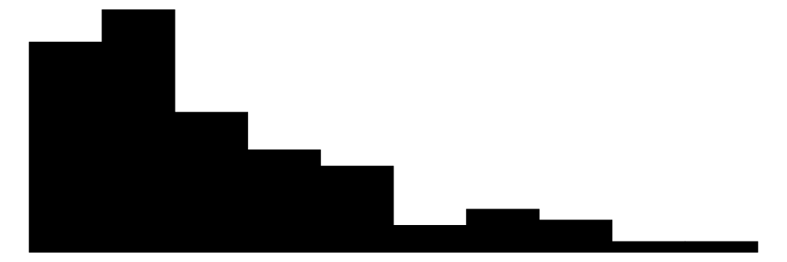

SFREQBUC

90

0

3.4

1.5

0.0

3.2

7.0

[figure not shown]

N

%

BREATH

buccal

104

61.9

lung

64

38.1

TOAD

a

8

4.8

b

8

4.8

c

8

4.8

d

8

4.8

e

8

4.8

f

8

4.8

g

8

4.8

h

8

4.8

i

8

4.8

j

8

4.8

k

8

4.8

l

8

4.8

m

8

4.8

n

8

4.8

o

8

4.8

p

8

4.8

q

8

4.8

r

8

4.8

s

8

4.8

t

8

4.8

u

8

4.8

```r
mullens |> modelsummary::datasummary_skim()
```

BREATH

O2LEVEL

Unique

Missing Pct.

Mean

SD

Min

Median

Max

Histogram

FREQBUC

lung

0.0

6

0

4.3

5.2

0.0

2.7

13.8

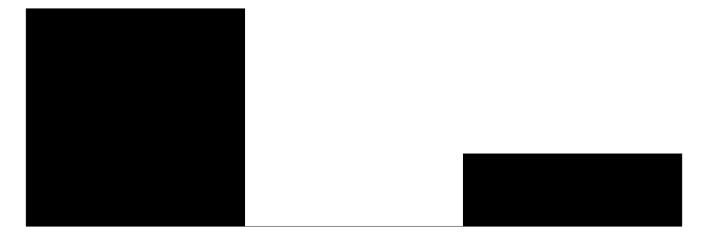

lung

5.0

6

0

8.2

7.7

0.0

5.3

18.8

[figure not shown]

lung

10.0

8

0

13.2

7.7

0.0

16.7

22.4

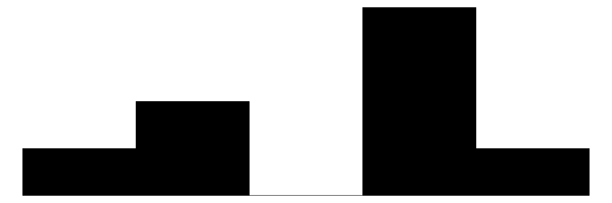

lung

15.0

8

0

11.4

8.2

0.0

10.6

27.0

[figure not shown]

lung

20.0

8

0

11.9

8.3

4.4

9.6

31.0

[figure not shown]

lung

30.0

8

0

10.2

6.7

3.8

8.7

25.0

[figure not shown]

lung

40.0

7

0

11.1

15.5

2.8

6.7

49.0

[figure not shown]

lung

50.0

8

0

7.2

5.8

2.8

5.3

21.0

[figure not shown]

buccal

0.0

12

0

25.7

11.4

8.4

28.0

45.8

[figure not shown]

buccal

5.0

12

0

23.6

11.2

7.6

21.4

44.0

[figure not shown]

buccal

10.0

12

0

20.2

9.0

9.6

16.2

38.0

[figure not shown]

buccal

15.0

13

0

17.9

10.4

5.2

16.8

40.2

[figure not shown]

buccal

20.0

12

0

12.7

8.1

3.0

9.4

29.2

[20 more figures not shown]

N

%

BREATH

buccal

104

61.9

lung

64

38.1

TOAD

a

8

4.8

b

8

4.8

c

8

4.8

d

8

4.8

e

8

4.8

f

8

4.8

g

8

4.8

h

8

4.8

i

8

4.8

j

8

4.8

k

8

4.8

l

8

4.8

m

8

4.8

n

8

4.8

o

8

4.8

p

8

4.8

q

8

4.8

r

8

4.8

s

8

4.8

t

8

4.8

u

8

4.8

```r
mullens |> modelsummary::datasummary_skim(by = c("BREATH", "O2LEVEL"))
```

# 4 Exploratory data analysis

In this example, the individual `TOAD`s are the random blocks. Each toad can only be of one `BREATH` type (they are either predominantly buccal breathers or predominantly lung breathers). Hence, `BREATH` is a between `TOAD` (block) effect. The frequency of buccal breathing of ach `TOAD` was measured under eight different oxygen levels and thus, these represent the within block effect, as will the interaction between breathing type and oxygen level.

The response in this case is a little tricky since it is a proportion, but without the full original measurements. For example a frequency of 50% would indicate that half of the breaths taken by the toad during the monitoring phase were buccal breaths. Ideally, it would be good to have the actual counts (both the number of buccal breaths and the total number of breaths). That way, we could model the data against a binomial distribution.

As it is, we only have the proportion (as a percentage). Although we could model this against a beta distribution, this could be complicated if there are proportions of either 0 or 1 (100).

To help guide us through this and the other typical model assumptions, lets start by graphing the frequency of buccal breathing against breathing type and oxygen level. However, before we do, we need to make sure that all categorical variables are declared as factors (including the random effect). If we intend to model against a beta distribution, we will need a version of the response that is represented on a scale between 0 and 1 (but not include 0 or 1).

```r
mullens <- mullens |>
  mutate(
    BREATH = factor(BREATH),
    TOAD = factor(TOAD),
    pBUC = FREQBUC / 100,
    pzBUC = ifelse(pBUC == 0, 0.01, pBUC)
  )
```

**Boxplots**

So starting with the raw response.

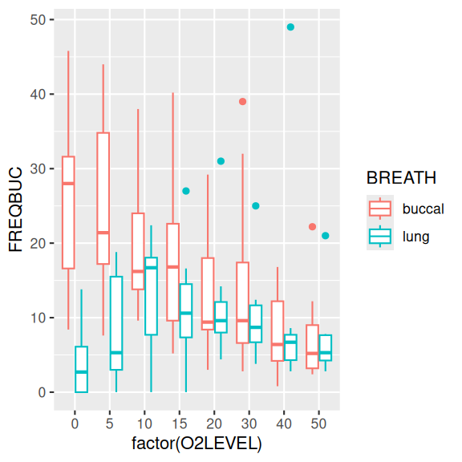

```r
ggplot(mullens, aes(y = FREQBUC, x = factor(O2LEVEL), color = BREATH)) +
  geom_boxplot()
```

**Conclusions:**

- there is a very clear relationship between mean and variance (boxplots that are higher up the y-axis are taller).
- it might be possible to address this via a logarithmic or root transformation, however this is the least favourable option (particularly root transformations due to issues with back-transformations).

**Scatterplot**

If we intend to use a beta distribution, we could repeat the above with the scaled response. Since the rescaling maintains the same ranking and relative spacing, the plot will look the same as above, just with a different y-axis. However, our interpretation will change. Under a beta distribution (with logit link), we expect that the variance and mean will be related. We expect that the distributions will become more varied and more symmetrical as the expected mean shifts towards 0.5. Distributions approaching 0 and 1 will be more asymmetrical and smaller. This indeed does seem to be the case here.

Now lets explore the oxygen trends (separately for each breathing type).

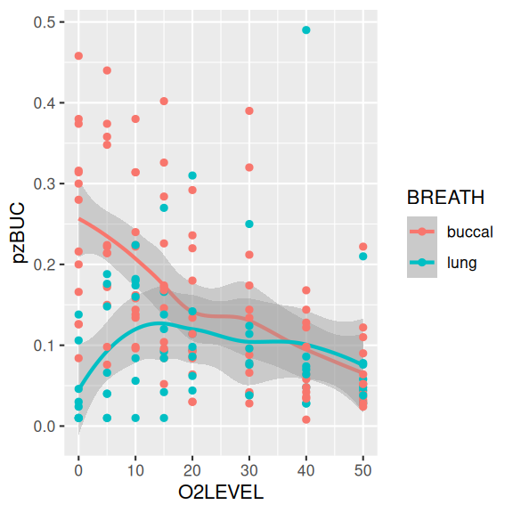

```r
ggplot(mullens, aes(y = pzBUC, x = O2LEVEL, color = BREATH)) +
  geom_smooth() +
  geom_point()
```

**Conclusions:**

- although linearity seems reasonable for the buccal breathers, there is definitely evidence of non linearity in the lung breathers.
- it might be interesting to fit polynomial trends for oxygen concentration.

**Facets**

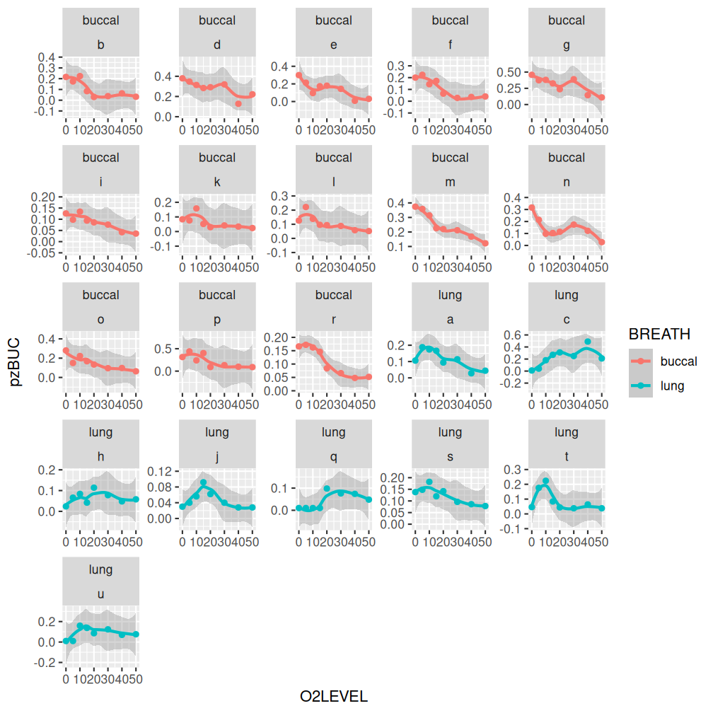

```r
ggplot(mullens, aes(y = pzBUC, x = O2LEVEL, color = BREATH)) +
  geom_smooth() +
  geom_point() +
  facet_wrap(~ BREATH + TOAD, scales = "free")
```

```r
# facet_grid(TOAD~BREATH)
```

**Conclusions:**

- it does appear that different toads (within the same breathing type) have very different levels of buccal breathing
- the individual toads also have varying responses to changes in oxygen concentration
- it might be useful to explore random intercept/slope models.

# 5 Fit the model

**beta**

**brms**

Explore the default priors

```r
mullens.form <- bf(pBUC ~ BREATH * poly(O2LEVEL, 3) + (1 | TOAD),
  family = zero_one_inflated_beta()
)
get_prior(mullens.form, data = mullens)
```

```
                prior     class                     coef group resp dpar nlpar
               (flat)         b
               (flat)         b               BREATHlung
               (flat)         b BREATHlung:polyO2LEVEL31
               (flat)         b BREATHlung:polyO2LEVEL32
               (flat)         b BREATHlung:polyO2LEVEL33
               (flat)         b            polyO2LEVEL31
               (flat)         b            polyO2LEVEL32
               (flat)         b            polyO2LEVEL33
           beta(1, 1)       coi
 student_t(3, 0, 2.5) Intercept
    gamma(0.01, 0.01)       phi
 student_t(3, 0, 2.5)        sd
 student_t(3, 0, 2.5)        sd                           TOAD
 student_t(3, 0, 2.5)        sd                Intercept  TOAD
           beta(1, 1)       zoi
 lb ub       source
            default
       (vectorized)
       (vectorized)
       (vectorized)
       (vectorized)
       (vectorized)
       (vectorized)
       (vectorized)
  0  1      default
            default
  0         default
  0         default
  0    (vectorized)
  0    (vectorized)
  0  1      default
```

```r
mullens |>
  group_by(BREATH) |>
  summarise(
    logit(median(pBUC)),
    logit(mad(pBUC))
  )
```

```
# A tibble: 2 × 3
  BREATH `logit(median(pBUC))` `logit(mad(pBUC))`
  <fct>                  <dbl>              <dbl>
1 buccal                 -1.87              -2.05
2 lung                   -2.48              -2.79
```

```r
median(logit(mullens$pBUC))
```

```
[1] -1.983737
```

```r
mad(logit(mullens$pBUC))
```

```
[1] 0.8044649
```

```r
sd(logit(mullens$pBUC)) / apply(model.matrix(~ BREATH * poly(O2LEVEL, 3), data = mullens), 2, sd)
```

```
                 (Intercept)                   BREATHlung
                         Inf                     1.641316
           poly(O2LEVEL, 3)1            poly(O2LEVEL, 3)2
                   10.331042                    10.331042
           poly(O2LEVEL, 3)3 BREATHlung:poly(O2LEVEL, 3)1
                   10.331042                    16.738202
BREATHlung:poly(O2LEVEL, 3)2 BREATHlung:poly(O2LEVEL, 3)3
                   16.738202                    16.738202
```

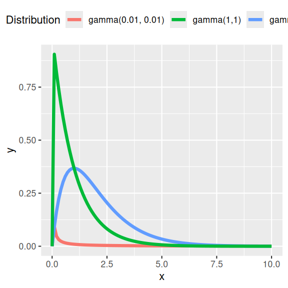

```r
standist::visualize("gamma(0.01, 0.01)", "gamma(2,1)", "gamma(1,1)", xlim = c(0, 10))
```

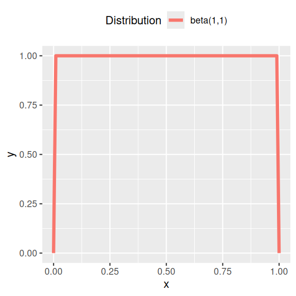

```r
standist::visualize("beta(1,1)", xlim = c(0, 1))
```

```r
priors <- prior(normal(-2, 2), class = "Intercept") +
  prior(normal(0, 1), class = "b") +
  ## prior(normal(0,1), class='b', coef = "BREATHlung") +
  # prior(gamma(2,1), class='sd') +
  prior(student_t(3, 0, 2), class = "sd") +
  prior(gamma(0.01, 0.01), class = "phi") +
  ## prior(gamma(2, 1), class='phi') +
  prior(beta(1, 1), class = "zoi") +
  prior(beta(1, 1), class = "coi")

mullens.form <- bf(pBUC ~ BREATH * poly(O2LEVEL, 3) + (1 | TOAD),
  family = zero_one_inflated_beta()
)

mullens.brm <- brm(mullens.form,
  data = mullens,
  prior = priors,
  sample_prior = "only",
  iter = 5000,
  warmup = 2500,
  thin = 5,
  chains = 3, cores = 3,
  refresh = 0,
  seed = 123,
  control = list(adapt_delta = 0.99, max_treedepth = 20),
  backend = "rstan"
)
```

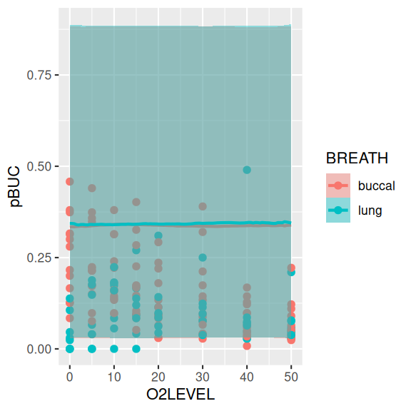

```r
mullens.brm |>
  conditional_effects(effects = "O2LEVEL:BREATH") |>
  plot(points = TRUE)
```

```r
mullens.brm2 <- update(mullens.brm,
  sample_prior = "yes", refresh = 0,
  cores = 3, seed = 123
)
```

```
The desired updates require recompiling the model
```

```r
priors <- prior(normal(-2, 2), class = "Intercept") +
  prior(normal(0, 2), class = "b") +
  prior(student_t(3, 0, 2), class = "sd") +
  prior(gamma(0.01, 0.01), class = "phi") +
  prior(beta(1, 1), class = "zoi") +
  prior(beta(1, 1), class = "coi")
mullens.brm3 <- update(mullens.brm2,
  prior = priors, refresh = 0,
  cores = 3, seed = 123
)
```

```
The desired updates require recompiling the model
```

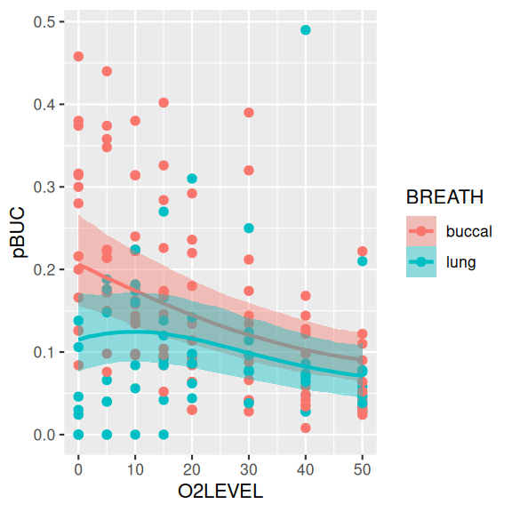

```r
mullens.brm2 |>
  conditional_effects(effects = "O2LEVEL:BREATH") |>
  plot(points = TRUE)
```

```
You are calculating adjusted predictions on the population-level (i.e.
  `type = "fixed"`) for a *generalized* linear mixed model.
  This may produce biased estimates due to Jensen's inequality. Consider
  setting `bias_correction = TRUE` to correct for this bias.
  See also the documentation of the `bias_correction` argument.
```

```
Note: uncertainty of error terms are not taken into account. Consider
  setting `interval` to "prediction". This will call `posterior_predict()`
  instead of `posterior_epred()`.
```

```
Data points may overlap. Use the `jitter` argument to add some amount of
  random variation to the location of data points and avoid overplotting.
```

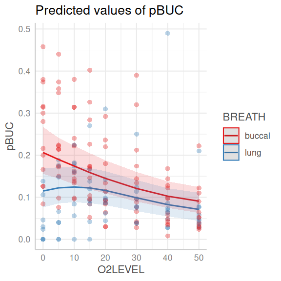

```r
mullens.brm2 |>
  ggpredict(~ O2LEVEL | BREATH) |>
  plot(show_data = TRUE, jitter = FALSE)
```

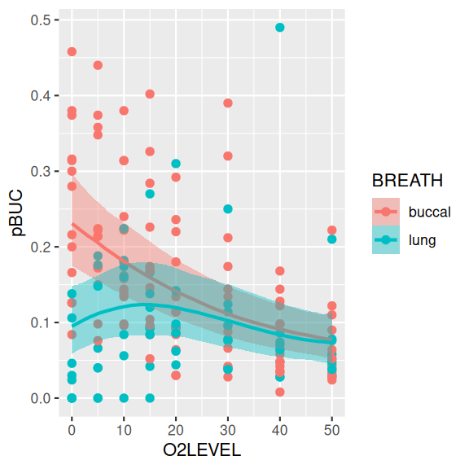

```r
mullens.brm3 |>
  conditional_effects(effects = "O2LEVEL:BREATH") |>
  plot(points = TRUE)
```

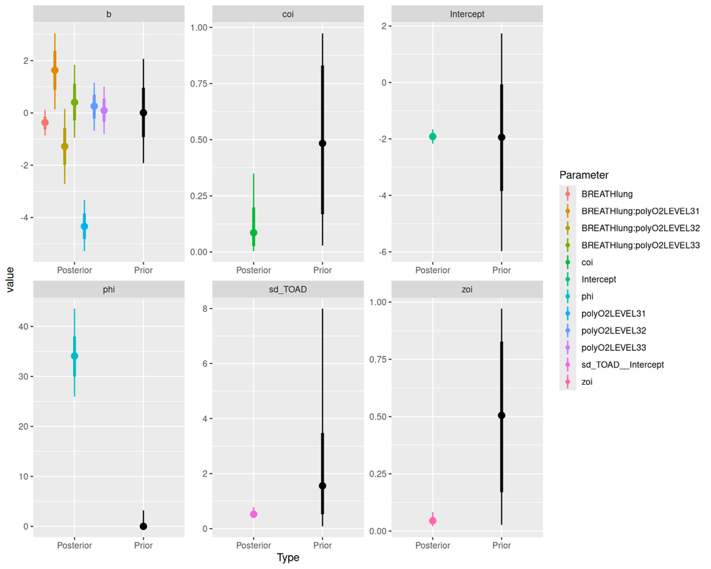

```r
mullens.brm2 |> SUYR_prior_and_posterior()
```

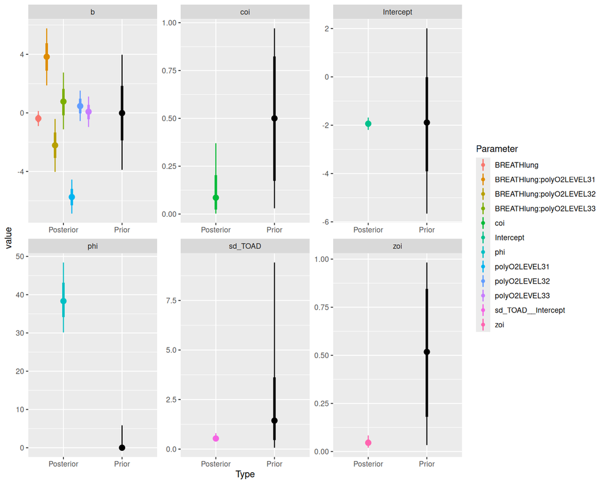

```r
mullens.brm3 |> SUYR_prior_and_posterior()
```

```r
mullens.brm3$fit |> stan_trace()
mullens.brm3$fit |> stan_ac()
mullens.brm3$fit |> stan_rhat()
mullens.brm3$fit |> stan_ess()
```

[output not shown]

# 6 Model validation

**brms**

**posterior probability checks**

```r
mullens.brm3 |> pp_check(type = "dens_overlay", ndraws = 200)

mullens.brm3 |> pp_check(group = "BREATH", type = "intervals_grouped")
mullens.brm3 |> pp_check(group = "O2LEVEL", type = "intervals_grouped")
```

[output not shown]

**DHARMa residuals**

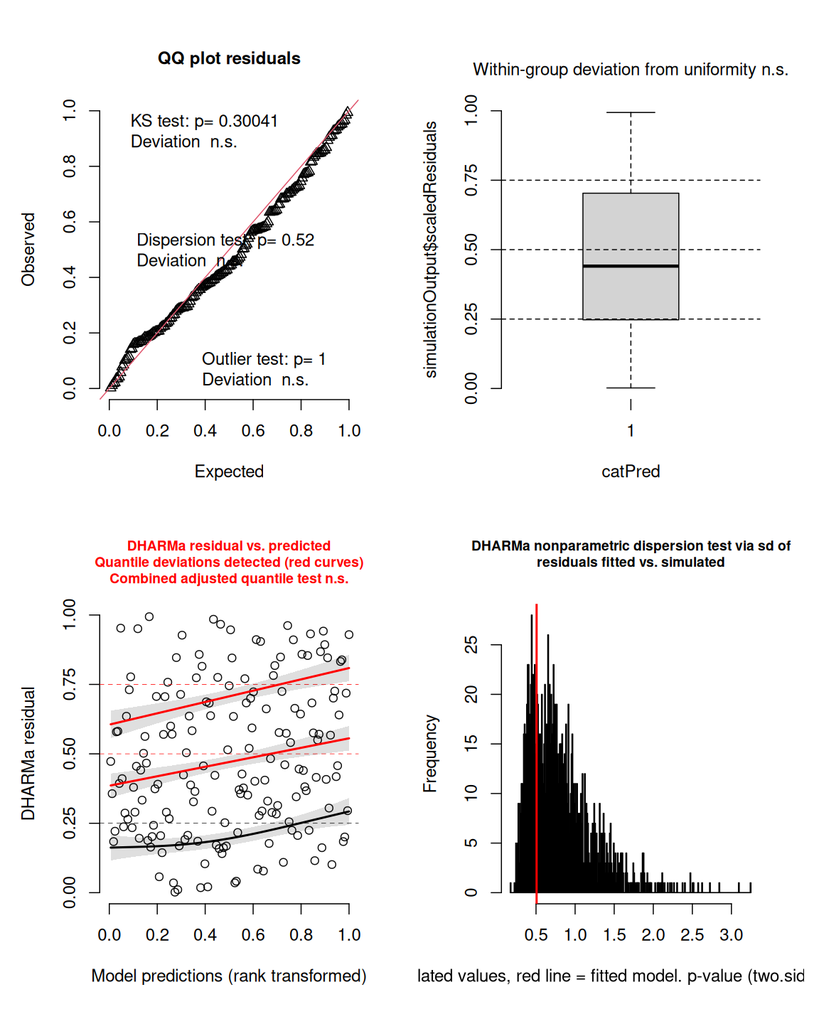

```r
mullens.resids <- make_brms_dharma_res(mullens.brm3, integerResponse = FALSE)
wrap_elements(~ testUniformity(mullens.resids)) +
  wrap_elements(~ plotResiduals(mullens.resids, form = factor(rep(1, nrow(mullens))))) +
  wrap_elements(~ plotResiduals(mullens.resids, quantreg = TRUE)) +
  wrap_elements(~ testDispersion(mullens.resids))
```

# 7 Partial effects plot

**brms**

**Conditional effects**

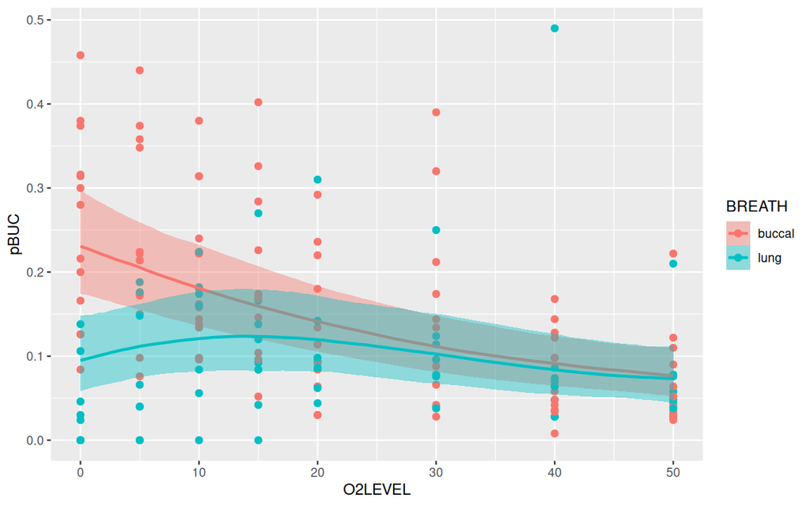

```r
mullens.brm3 |>
  conditional_effects(effects = "O2LEVEL:BREATH") |>
  plot(points = TRUE)
```

## 7.1 ggpredict

```
Note: uncertainty of error terms are not taken into account. Consider
  setting `interval` to "prediction". This will call `posterior_predict()`
  instead of `posterior_epred()`.
```

```
Data points may overlap. Use the `jitter` argument to add some amount of
  random variation to the location of data points and avoid overplotting.
```

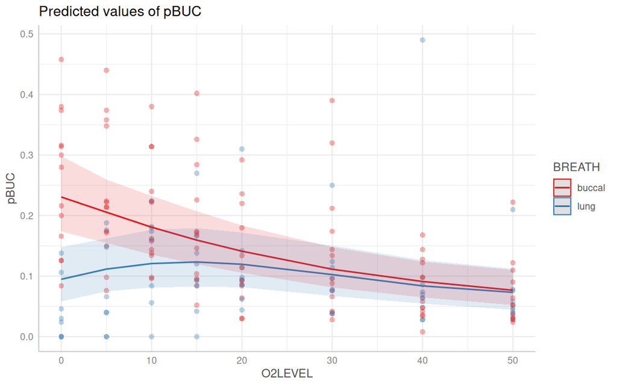

```r
mullens.brm3 |>
  ggpredict(~ O2LEVEL | BREATH) |>
  plot(show_data = TRUE, jitter = FALSE)
```

## 7.2 ggemmeans

```
Data points may overlap. Use the `jitter` argument to add some amount of
  random variation to the location of data points and avoid overplotting.
```

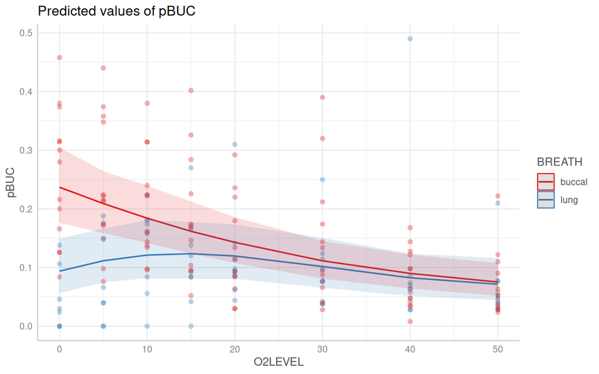

```r
mullens.brm3 |>
  ggemmeans(~ O2LEVEL | BREATH) |>
  plot(show_data = TRUE, jitter = FALSE)
```

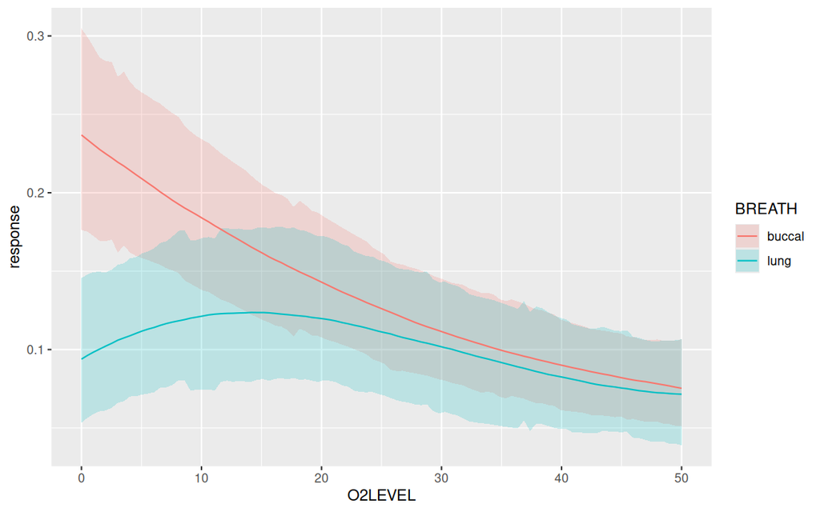

```r
newdata <- with(mullens, list(
  O2LEVEL = seq(min(O2LEVEL), max(O2LEVEL), len = 100),
  BREATH = levels(BREATH)
))

mullens.em <-
  mullens.brm3 |>
  emmeans(~ O2LEVEL | BREATH, at = newdata, type = "response") |>
  as.data.frame()
mullens.em |>
  ggplot(aes(y = response, x = O2LEVEL, colour = BREATH, fill = BREATH)) +
  geom_ribbon(aes(ymin = lower.HPD, ymax = upper.HPD),
    alpha = 0.2, colour = NA
  ) +
  geom_line()
```

# 8 Model investigation

**brms**

**summary**

```r
mullens.brm2 |> summary()
```

```
 Family: zero_one_inflated_beta
  Links: mu = logit; phi = identity; zoi = identity; coi = identity
Formula: pBUC ~ BREATH * poly(O2LEVEL, 3) + (1 | TOAD)
   Data: mullens (Number of observations: 168)
  Draws: 3 chains, each with iter = 5000; warmup = 2500; thin = 5;
         total post-warmup draws = 1500

Multilevel Hyperparameters:
~TOAD (Number of levels: 21)
              Estimate Est.Error l-95% CI u-95% CI Rhat Bulk_ESS Tail_ESS
sd(Intercept)     0.54      0.11     0.38     0.78 1.00     1226     1349

Regression Coefficients:
                         Estimate Est.Error l-95% CI u-95% CI Rhat Bulk_ESS
Intercept                   -1.77      0.16    -2.09    -1.46 1.00     1121
BREATHlung                  -0.38      0.25    -0.86     0.12 1.00     1303
polyO2LEVEL31               -4.34      0.50    -5.29    -3.33 1.00     1549
polyO2LEVEL32                0.25      0.48    -0.68     1.16 1.00     1438
polyO2LEVEL33                0.10      0.47    -0.80     1.01 1.00     1543
BREATHlung:polyO2LEVEL31     1.62      0.77     0.13     3.04 1.00     1401
BREATHlung:polyO2LEVEL32    -1.28      0.74    -2.72     0.15 1.00     1511
BREATHlung:polyO2LEVEL33     0.42      0.72    -0.95     1.84 1.00     1435
                         Tail_ESS
Intercept                    1141
BREATHlung                   1457
polyO2LEVEL31                1496
polyO2LEVEL32                1460
polyO2LEVEL33                1413
BREATHlung:polyO2LEVEL31     1486
BREATHlung:polyO2LEVEL32     1383
BREATHlung:polyO2LEVEL33     1497

Further Distributional Parameters:
    Estimate Est.Error l-95% CI u-95% CI Rhat Bulk_ESS Tail_ESS
phi    34.18      4.44    25.97    43.57 1.00     1466     1333
zoi     0.05      0.02     0.02     0.08 1.00     1530     1313
coi     0.11      0.10     0.00     0.35 1.00     1407     1314

Draws were sampled using sampling(NUTS). For each parameter, Bulk_ESS
and Tail_ESS are effective sample size measures, and Rhat is the potential
scale reduction factor on split chains (at convergence, Rhat = 1).
```

**as_draws_df()**

```r
mullens.brm3 |>
  as_draws_df() |>
  mutate(across(everything(), exp)) |>
  dplyr::select(matches("^b_.*|^sd_.*")) |>
  summarise_draws(
    median,
    HDInterval::hdi,
    rhat,
    length,
    ess_bulk, ess_tail,
    Pl = ~ mean(.x < 1),
    Pg = ~ mean(.x > 1)
  ) |>
  knitr::kable()
```

| variable | median | lower | upper | rhat | length | ess_bulk | ess_tail | Pl | Pg |
| --- | --- | --- | --- | --- | --- | --- | --- | --- | --- |
| b_Intercept | 0.1670042 | 0.1189784 | 0.2250192 | 1.0018252 | 1500 | 962.8235 | 1102.214 | 1.0000000 | 0.0000000 |
| b_BREATHlung | 0.6836448 | 0.3720328 | 1.0847048 | 1.0003004 | 1500 | 1051.6154 | 1110.226 | 0.9366667 | 0.0633333 |
| b_polyO2LEVEL31 | 0.0031985 | 0.0007305 | 0.0084637 | 0.9997699 | 1500 | 1290.7153 | 1530.815 | 1.0000000 | 0.0000000 |
| b_polyO2LEVEL32 | 1.5942031 | 0.3869634 | 3.8228459 | 0.9999437 | 1500 | 1503.3559 | 1280.052 | 0.1880000 | 0.8120000 |
| b_polyO2LEVEL33 | 1.0841982 | 0.2266756 | 2.5565466 | 1.0004433 | 1500 | 1462.1332 | 1307.588 | 0.4380000 | 0.5620000 |
| b_BREATHlung:polyO2LEVEL31 | 46.1674803 | 0.9903850 | 226.9142129 | 0.9996964 | 1500 | 1528.7125 | 1340.766 | 0.0006667 | 0.9993333 |
| b_BREATHlung:polyO2LEVEL32 | 0.1092211 | 0.0071674 | 0.5038358 | 1.0070014 | 1500 | 1677.8320 | 1403.666 | 0.9953333 | 0.0046667 |
| b_BREATHlung:polyO2LEVEL33 | 2.1747581 | 0.1256471 | 11.6626643 | 1.0002384 | 1500 | 1515.7266 | 1524.102 | 0.2246667 | 0.7753333 |
| sd_TOAD__Intercept | 1.7069957 | 1.4309808 | 2.1585563 | 1.0001341 | 1500 | 948.3748 | 1270.547 | 0.0000000 | 1.0000000 |

```r
mean(mullens$O2LEVEL)
```

```
[1] 21.25
```

```r
0.163 / (1 + 0.163)
```

```
[1] 0.1401548
```

```r
mullens.brm3 |>
  as_draws_df() |>
  dplyr::select(matches("^b_.*")) |>
  exp() |>
  summarise_draws(
    median,
    HDInterval::hdi,
    rhat,
    length,
    ess_bulk, ess_tail,
    Pl = ~ mean(.x < 1),
    Pg = ~ mean(.x > 1)
  )
```

```
# A tibble: 8 × 10
  variable         median   lower   upper  rhat length ess_bulk ess_tail      Pl
  <chr>             <dbl>   <dbl>   <dbl> <dbl>  <dbl>    <dbl>    <dbl>   <dbl>
1 b_Intercept     1.67e-1 1.19e-1 2.25e-1 1.00    1500     963.    1102. 1   e+0
2 b_BREATHlung    6.84e-1 3.72e-1 1.08e+0 1.00    1500    1052.    1110. 9.37e-1
3 b_polyO2LEVEL31 3.20e-3 7.30e-4 8.46e-3 1.000   1500    1291.    1531. 1   e+0
4 b_polyO2LEVEL32 1.59e+0 3.87e-1 3.82e+0 1.000   1500    1503.    1280. 1.88e-1
5 b_polyO2LEVEL33 1.08e+0 2.27e-1 2.56e+0 1.00    1500    1462.    1308. 4.38e-1
6 b_BREATHlung:p… 4.62e+1 9.90e-1 2.27e+2 1.000   1500    1529.    1341. 6.67e-4
7 b_BREATHlung:p… 1.09e-1 7.17e-3 5.04e-1 1.01    1500    1678.    1404. 9.95e-1
8 b_BREATHlung:p… 2.17e+0 1.26e-1 1.17e+1 1.00    1500    1516.    1524. 2.25e-1
# ℹ 1 more variable: Pg <dbl>
```

```r
mullens.brm2 |> performance::r2()
```

```
# Bayesian R2 with Compatibility Interval

  Conditional R2: 0.553 (95% CI [0.452, 0.632])
     Marginal R2: 0.154 (95% CI [0.062, 0.287])
```

```r
mullens.brm2 |>
  performance::r2_posterior() |>
  as.data.frame() |>
  median_hdci()
```

```
   R2_Bayes R2_Bayes.lower R2_Bayes.upper R2_Bayes_marginal
1 0.5530387      0.4617761      0.6421551         0.1535782
  R2_Bayes_marginal.lower R2_Bayes_marginal.upper .width .point .interval
1              0.06248566               0.2872945   0.95 median      hdci
```

# 9 Further investigations

```r
mullens.brm3 |> emtrends(specs = "BREATH", var = "O2LEVEL", max.degree = 3)
```

```
degree = linear:
 BREATH O2LEVEL.trend lower.HPD upper.HPD
 buccal     -2.91e-02 -4.13e-02 -1.61e-02
 lung       -1.41e-02 -3.50e-02  4.50e-03

degree = quadratic:
 BREATH O2LEVEL.trend lower.HPD upper.HPD
 buccal      1.44e-04 -2.94e-04  5.07e-04
 lung       -7.83e-04 -1.48e-03 -1.06e-04

degree = cubic:
 BREATH O2LEVEL.trend lower.HPD upper.HPD
 buccal      1.99e-06 -2.58e-05  2.51e-05
 lung        2.08e-05 -2.26e-05  6.09e-05

Point estimate displayed: median
HPD interval probability: 0.95
```

```r
mullens.brm3 |>
  emtrends(specs = "BREATH", var = "O2LEVEL", max.degree = 3) |>
  gather_emmeans_draws() |>
  summarise(median_hdci(.value),
    Pl = mean(.value < 0),
    Pg = mean(.value > 0)
  )
```

```
# A tibble: 6 × 10
# Groups:   BREATH [2]
  BREATH degree         y     ymin     ymax .width .point .interval    Pl     Pg
  <fct>  <fct>      <dbl>    <dbl>    <dbl>  <dbl> <chr>  <chr>     <dbl>  <dbl>
1 buccal linear  -2.91e-2 -4.13e-2 -1.61e-2   0.95 median hdci      1     0
2 buccal quadra…  1.44e-4 -2.87e-4  5.17e-4   0.95 median hdci      0.254 0.746
3 buccal cubic    1.99e-6 -2.20e-5  2.89e-5   0.95 median hdci      0.438 0.562
4 lung   linear  -1.41e-2 -3.54e-2  4.15e-3   0.95 median hdci      0.913 0.0867
5 lung   quadra… -7.83e-4 -1.50e-3 -1.18e-4   0.95 median hdci      0.985 0.0147
6 lung   cubic    2.08e-5 -2.26e-5  6.09e-5   0.95 median hdci      0.167 0.833
```

```r
mullens.brm3 |>
  emmeans(~ BREATH | O2LEVEL, at = list(O2LEVEL = c(0, 21, 50))) |>
  pairs() |>
  gather_emmeans_draws() |>
  mutate(.value = exp(.value)) |>
  summarise(median_hdci(.value),
    Pl = mean(.value < 1),
    Pg = mean(.value > 1)
  )
```

```
# A tibble: 3 × 10
# Groups:   contrast [1]
  contrast      O2LEVEL     y  ymin  ymax .width .point .interval       Pl    Pg
  <fct>           <dbl> <dbl> <dbl> <dbl>  <dbl> <chr>  <chr>        <dbl> <dbl>
1 buccal - lung       0  2.97 1.36   5.19   0.95 median hdci      0.000667 0.999
2 buccal - lung      21  1.19 0.604  1.92   0.95 median hdci      0.257    0.743
3 buccal - lung      50  1.06 0.522  1.91   0.95 median hdci      0.424    0.576
```

```r
mullens.grid <- with(
  mullens,
  list(
    O2LEVEL = seq(min(O2LEVEL), max(O2LEVEL), len = 1000),
    BREATH = levels(BREATH)
  )
)
## mullens.grid <- with(mullens,
##   list(O2LEVEL = modelr::seq_range(O2LEVEL, n = 1000),
##     BREATH = levels(BREATH)))

## At what point does the evidence for the curves being different stop
mullens.brm3 |>
  emmeans(~ BREATH | O2LEVEL, at = mullens.grid) |>
  pairs() |>
  gather_emmeans_draws() |>
  mutate(.value = exp(.value)) |>
  summarise(median_hdci(.value),
    Pl = mean(.value < 1),
    Pg = mean(.value > 1)
  ) |>
  filter(Pg < 0.90) |>
  slice(1:3)
```

```
# A tibble: 3 × 10
# Groups:   contrast [1]
  contrast      O2LEVEL     y  ymin  ymax .width .point .interval    Pl    Pg
  <fct>           <dbl> <dbl> <dbl> <dbl>  <dbl> <chr>  <chr>     <dbl> <dbl>
1 buccal - lung    13.6  1.43 0.757  2.31   0.95 median hdci      0.101 0.899
2 buccal - lung    13.6  1.42 0.756  2.30   0.95 median hdci      0.101 0.899
3 buccal - lung    13.7  1.42 0.764  2.31   0.95 median hdci      0.103 0.897
```

```r
## Find the peak
newdata <- mullens.brm3 |>
  emmeans(~ O2LEVEL | BREATH, at = mullens.grid) |>
  as.data.frame()
newdata |>
  group_by(BREATH) |>
  summarise(value = O2LEVEL[which.max(emmean)])
```

```
# A tibble: 2 × 2
  BREATH value
  <fct>  <dbl>
1 buccal   0
2 lung    14.1
```

```r
## With uncertainty
mullens.brm3 |>
  emmeans(~ O2LEVEL | BREATH, at = mullens.grid) |>
  gather_emmeans_draws() |>
  group_by(.draw, BREATH) |>
  summarise(value = O2LEVEL[which.max(.value)]) |>
  ungroup() |>
  group_by(BREATH) |>
  summarise(median_hdci(value))
```

```
# A tibble: 2 × 7
  BREATH     y  ymin  ymax .width .point .interval
  <fct>  <dbl> <dbl> <dbl>  <dbl> <chr>  <chr>
1 buccal   0       0   0     0.95 median hdci
2 lung    14.1     0  22.8   0.95 median hdci
```

```r
# Or via Derivatives
## mullens.brm3 |> estimate_slopes(trend =  "O2LEVEL",
##   at = c("BREATH='lung'","O2LEVEL"))

## mullens.brm2 |>
##   emtrends(~O2LEVEL|BREATH, var = "O2LEVEL",
##     cov.red = \(x) seq(min(x), max(x), length = 10)
##   ) |>
##   summary() |>
##   ggplot(aes(y = O2LEVEL.trend, x = O2LEVEL, colour =  BREATH)) +
##   geom_hline(yintercept = 0, linetype = "dashed") +
##   geom_ribbon(aes(ymin = lower.HPD, ymax = upper.HPD, fill = BREATH), alpha = 0.2) +
##   geom_line()
```